# BIOL390: Assignment 2

Paige Beffrey

December 23, 2021

**Description:** Results from an experiment to compare yields (as measured by dried weight of plants) obtained under a control and two different treatment conditions.

**Source:** Dobson, A. J. (1983) *An Introduction to Statistical Modelling*. London: Chapman and Hall.

## Analysis

> > Replace the `XXX` in the code below with the necessary R instructions to give the mean values for each factor level of this dataset in a pretty little table. Hint - the comparison and dataset are the same as in the barplot. You will want to use the function (FUN) of `mean`.

| group | weight |
| --- | --- |
| ctrl | 5.032 |
| trt1 | 4.661 |
| trt2 | 5.526 |

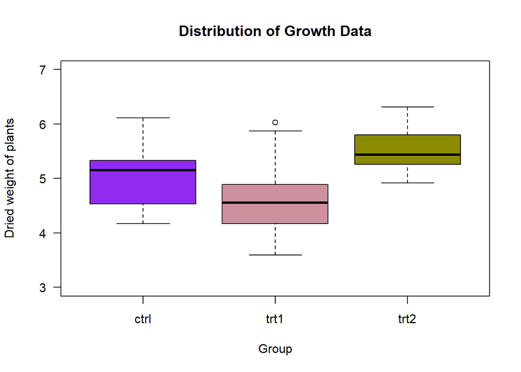

```r
boxplot(weight ~ group,                             # compare weight by group
        data = PlantGrowth,                         # built-in data set
        main = "Distribution of Growth Data",       # set title
        las = 1,                                    # rotate y-axis values
        ylab = "Dried weight of plants",            # set y-axis title
        xlab = "Group",                             # set x-axis title
        ylim = c(3,7),                              # set scale of y-axis
        col = c("purple2","pink3","yellow4"))       # set bar fill colors
```

> > Edit the barplot above so that the y-axis range plotted is from 3 to 7 and change the colors of the bars to something that you find fun.

```r
knitr::kable(anova(lm(weight ~ group, data = PlantGrowth)),digits = 3)
```

|  | Df | Sum Sq | Mean Sq | F value | Pr(>F) |
| --- | --- | --- | --- | --- | --- |
| group | 2 | 3.766 | 1.883 | 4.846 | 0.016 |
| Residuals | 27 | 10.492 | 0.389 | NA | NA |

> > Provide a short summary of the ANOVA analysis summarized above. The analysis is compairing dried weight of plants between three different plant groups. It is showing how the dried weight is distrubuted between each group.